# Group Activity: Report on Data Exploration Techniques

## Group Information

**Group Name:** Group Nime

**Group Leader:** Mark Kenneth S. Badilla

**Group Members:**

- James Alein Ocampo
- Alestair Cyril Coyoca
- Rob S. Borinaga
- Carmelyn Nime T. Gerali

## Introduction

In this activity, our group, Group Nime, explores the Invistico Airline Dataset sourced from Kaggle. This dataset contains customer satisfaction information, including both numerical and categorical variables, for an airline. The primary objective is to perform data exploration using basic descriptive statistics to understand the central tendencies, spread, and relationships within the dataset.

Our analysis involves cleaning the dataset, performing statistical calculations, and visualizing the results using tools like pandas, numpy, scipy, and matplotlib. By the end of this report, we aim to present insights into the dataset and identify potential areas for further analysis.

```python
# Set Up the Environment and Import Libraries

import pandas as pd
import numpy as np
import matplotlib.pyplot as plt
import seaborn as sns

%matplotlib inline
```

```python
# Load the Dataset

df = pd.read_csv('Invistico_Airline.csv')
```

```python
# Initial Data Exploration

df.head()
```

|  | satisfaction | Gender | Customer Type | Age | Type of Travel | Class | Flight Distance | Seat comfort | Departure/Arrival time convenient | Food and drink | ... | Online support | Ease of Online booking | On-board service | Leg room service | Baggage handling | Checkin service | Cleanliness | Online boarding | Departure Delay in Minutes | Arrival Delay in Minutes |
| --- | --- | --- | --- | --- | --- | --- | --- | --- | --- | --- | --- | --- | --- | --- | --- | --- | --- | --- | --- | --- | --- |
| 0 | satisfied | Female | Loyal Customer | 65 | Personal Travel | Eco | 265 | 0 | 0 | 0 | ... | 2 | 3 | 3 | 0 | 3 | 5 | 3 | 2 | 0 | 0.0 |
| 1 | satisfied | Male | Loyal Customer | 47 | Personal Travel | Business | 2464 | 0 | 0 | 0 | ... | 2 | 3 | 4 | 4 | 4 | 2 | 3 | 2 | 310 | 305.0 |
| 2 | satisfied | Female | Loyal Customer | 15 | Personal Travel | Eco | 2138 | 0 | 0 | 0 | ... | 2 | 2 | 3 | 3 | 4 | 4 | 4 | 2 | 0 | 0.0 |
| 3 | satisfied | Female | Loyal Customer | 60 | Personal Travel | Eco | 623 | 0 | 0 | 0 | ... | 3 | 1 | 1 | 0 | 1 | 4 | 1 | 3 | 0 | 0.0 |
| 4 | satisfied | Female | Loyal Customer | 70 | Personal Travel | Eco | 354 | 0 | 0 | 0 | ... | 4 | 2 | 2 | 0 | 2 | 4 | 2 | 5 | 0 | 0.0 |

5 rows × 23 columns

We start by displaying the first few rows of the dataset to get an initial understanding of the data structure and variables.

```python
df.info()
```

```
<class 'pandas.core.frame.DataFrame'>
RangeIndex: 129880 entries, 0 to 129879
Data columns (total 23 columns):
 #   Column                             Non-Null Count   Dtype
---  ------                             --------------   -----
 0   satisfaction                       129880 non-null  object
 1   Gender                             129880 non-null  object
 2   Customer Type                      129880 non-null  object
 3   Age                                129880 non-null  int64
 4   Type of Travel                     129880 non-null  object
 5   Class                              129880 non-null  object
 6   Flight Distance                    129880 non-null  int64
 7   Seat comfort                       129880 non-null  int64
 8   Departure/Arrival time convenient  129880 non-null  int64
 9   Food and drink                     129880 non-null  int64
 10  Gate location                      129880 non-null  int64
 11  Inflight wifi service              129880 non-null  int64
 12  Inflight entertainment             129880 non-null  int64
 13  Online support                     129880 non-null  int64
 14  Ease of Online booking             129880 non-null  int64
 15  On-board service                   129880 non-null  int64
 16  Leg room service                   129880 non-null  int64
 17  Baggage handling                   129880 non-null  int64
 18  Checkin service                    129880 non-null  int64
 19  Cleanliness                        129880 non-null  int64
 20  Online boarding                    129880 non-null  int64
 21  Departure Delay in Minutes         129880 non-null  int64
 22  Arrival Delay in Minutes           129487 non-null  float64
dtypes: float64(1), int64(17), object(5)
memory usage: 22.8+ MB
```

The `info()` method provides a concise summary of the DataFrame, including the number of non-null entries and data types of each column.

```python
df.isnull().sum()
```

```
satisfaction                           0
Gender                                 0
Customer Type                          0
Age                                    0
Type of Travel                         0
Class                                  0
Flight Distance                        0
Seat comfort                           0
Departure/Arrival time convenient      0
Food and drink                         0
Gate location                          0
Inflight wifi service                  0
Inflight entertainment                 0
Online support                         0
Ease of Online booking                 0
On-board service                       0
Leg room service                       0
Baggage handling                       0
Checkin service                        0
Cleanliness                            0
Online boarding                        0
Departure Delay in Minutes             0
Arrival Delay in Minutes             393
dtype: int64
```

We check for missing values in each column to identify any potential issues that need to be addressed during data cleaning.

```python
df.describe()
```

|  | Age | Flight Distance | Seat comfort | Departure/Arrival time convenient | Food and drink | Gate location | Inflight wifi service | Inflight entertainment | Online support | Ease of Online booking | On-board service | Leg room service | Baggage handling | Checkin service | Cleanliness | Online boarding | Departure Delay in Minutes | Arrival Delay in Minutes |
| --- | --- | --- | --- | --- | --- | --- | --- | --- | --- | --- | --- | --- | --- | --- | --- | --- | --- | --- |
| count | 129880.000000 | 129880.000000 | 129880.000000 | 129880.000000 | 129880.000000 | 129880.000000 | 129880.000000 | 129880.000000 | 129880.000000 | 129880.000000 | 129880.000000 | 129880.000000 | 129880.000000 | 129880.000000 | 129880.000000 | 129880.000000 | 129880.000000 | 129487.000000 |
| mean | 39.427957 | 1981.409055 | 2.838597 | 2.990645 | 2.851994 | 2.990422 | 3.249130 | 3.383477 | 3.519703 | 3.472105 | 3.465075 | 3.485902 | 3.695673 | 3.340807 | 3.705759 | 3.352587 | 14.713713 | 15.091129 |
| std | 15.119360 | 1027.115606 | 1.392983 | 1.527224 | 1.443729 | 1.305970 | 1.318818 | 1.346059 | 1.306511 | 1.305560 | 1.270836 | 1.292226 | 1.156483 | 1.260582 | 1.151774 | 1.298715 | 38.071126 | 38.465650 |
| min | 7.000000 | 50.000000 | 0.000000 | 0.000000 | 0.000000 | 0.000000 | 0.000000 | 0.000000 | 0.000000 | 0.000000 | 0.000000 | 0.000000 | 1.000000 | 0.000000 | 0.000000 | 0.000000 | 0.000000 | 0.000000 |
| 25% | 27.000000 | 1359.000000 | 2.000000 | 2.000000 | 2.000000 | 2.000000 | 2.000000 | 2.000000 | 3.000000 | 2.000000 | 3.000000 | 2.000000 | 3.000000 | 3.000000 | 3.000000 | 2.000000 | 0.000000 | 0.000000 |
| 50% | 40.000000 | 1925.000000 | 3.000000 | 3.000000 | 3.000000 | 3.000000 | 3.000000 | 4.000000 | 4.000000 | 4.000000 | 4.000000 | 4.000000 | 4.000000 | 3.000000 | 4.000000 | 4.000000 | 0.000000 | 0.000000 |
| 75% | 51.000000 | 2544.000000 | 4.000000 | 4.000000 | 4.000000 | 4.000000 | 4.000000 | 4.000000 | 5.000000 | 5.000000 | 4.000000 | 5.000000 | 5.000000 | 4.000000 | 5.000000 | 4.000000 | 12.000000 | 13.000000 |
| max | 85.000000 | 6951.000000 | 5.000000 | 5.000000 | 5.000000 | 5.000000 | 5.000000 | 5.000000 | 5.000000 | 5.000000 | 5.000000 | 5.000000 | 5.000000 | 5.000000 | 5.000000 | 5.000000 | 1592.000000 | 1584.000000 |

The `describe()` method generates descriptive statistics that summarize the central tendency, dispersion, and shape of the dataset's distribution, excluding NaN values.

# Data Cleaning

Based on the initial exploration, we proceed to clean the data to prepare it for analysis.

## Handling Missing Values

We observed that the 'Arrival Delay in Minutes' column has missing values. Since the missing values are a small fraction of the dataset, we decide to remove these rows.

```python
# Drop rows with missing 'Arrival Delay in Minutes'
df = df.dropna(subset=['Arrival Delay in Minutes'])
```

## Data Type Conversion

We convert categorical columns to the 'category' data type for more efficient memory usage and better analysis.

```python
# Convert categorical columns to 'category' data type
categorical_cols = ['satisfaction', 'Gender', 'Customer Type', 'Type of Travel', 'Class']
for col in categorical_cols:
    df[col] = df[col].astype('category')

# Convert 'Arrival Delay in Minutes' to integer type
df['Arrival Delay in Minutes'] = df['Arrival Delay in Minutes'].astype(int)
```

## Check for Duplicates

We check for and remove any duplicate rows to ensure data integrity.

```python
# Remove duplicate rows if any
df = df.drop_duplicates()
```

## Outlier Detection and Handling

We detect and handle outliers in 'Departure Delay in Minutes' and 'Arrival Delay in Minutes' by capping them at the 99th percentile.

```python
# Cap outliers at the 99th percentile
departure_delay_cap = df['Departure Delay in Minutes'].quantile(0.99)
arrival_delay_cap = df['Arrival Delay in Minutes'].quantile(0.99)

df['Departure Delay in Minutes'] = np.where(
    df['Departure Delay in Minutes'] > departure_delay_cap,
    departure_delay_cap,
    df['Departure Delay in Minutes']
)

df['Arrival Delay in Minutes'] = np.where(
    df['Arrival Delay in Minutes'] > arrival_delay_cap,
    arrival_delay_cap,
    df['Arrival Delay in Minutes']
)
```

# Data Exploration

We now perform exploratory data analysis using visualizations to understand the distributions and relationships in the data.

```python
# Define numerical columns
numerical_cols = [
    'Age', 'Flight Distance', 'Departure Delay in Minutes', 'Arrival Delay in Minutes'
]
```

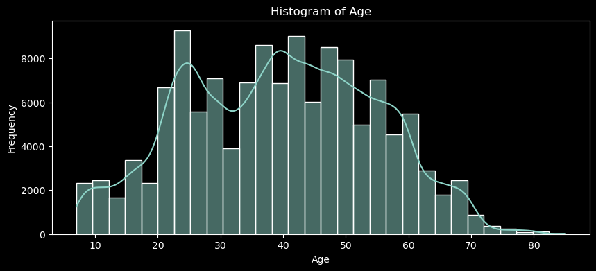

```python
# Histogram of Age
plt.figure(figsize=(10, 4))
sns.histplot(df['Age'], bins=30, kde=True)
plt.title('Histogram of Age')
plt.xlabel('Age')
plt.ylabel('Frequency')
plt.show()
```

```python
# Numerical Summary of Age
mean_Age = df['Age'].mean()
median_Age = df['Age'].median()
std_Age = df['Age'].std()
min_Age = df['Age'].min()
max_Age = df['Age'].max()
print(f"Mean: {mean_Age:.2f}")
print(f"Median: {median_Age:.2f}")
print(f"Standard Deviation: {std_Age:.2f}")
print(f"Minimum: {min_Age:.2f}")
print(f"Maximum: {max_Age:.2f}")
```

```
Mean: 39.43
Median: 40.00
Standard Deviation: 15.12
Minimum: 7.00
Maximum: 85.00
```

### Insights from Histogram of Age

- The **Age** distribution is approximately symmetrical with a slight right skew, indicating a slightly larger number of younger passengers.
- The mean age is around **39 years**, with the majority of passengers between **27 and 51 years old**.
- This suggests that the airline caters to a wide range of age groups, but with a concentration in the working-age population.
- There are no significant outliers in terms of age, indicating a consistent customer base.

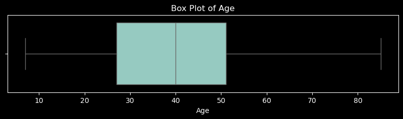

```python
# Box Plot of Age
plt.figure(figsize=(10, 2))
sns.boxplot(x=df['Age'])
plt.title('Box Plot of Age')
plt.xlabel('Age')
plt.show()
```

```python
# Quartiles and IQR of Age
Q1_Age = df['Age'].quantile(0.25)
Q2_Age = df['Age'].quantile(0.5)
Q3_Age = df['Age'].quantile(0.75)
IQR_Age = Q3_Age - Q1_Age
print(f"25th Percentile (Q1): {Q1_Age:.2f}")
print(f"50th Percentile (Median): {Q2_Age:.2f}")
print(f"75th Percentile (Q3): {Q3_Age:.2f}")
print(f"Interquartile Range (IQR): {IQR_Age:.2f}")
```

```
25th Percentile (Q1): 27.00
50th Percentile (Median): 40.00
75th Percentile (Q3): 51.00
Interquartile Range (IQR): 24.00
```

### Insights from Box Plot of Age

- The box plot confirms the Age distribution is fairly symmetrical.
- The IQR spans from **27 to 51 years**, indicating that 50% of passengers fall within this age range.
- There are minimal outliers, suggesting a consistent age demographic.
- This information can be valuable for targeted marketing and service offerings.

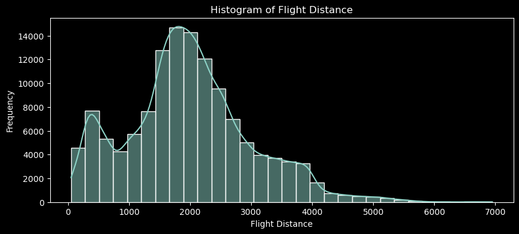

```python
# Histogram of Flight Distance
plt.figure(figsize=(10, 4))
sns.histplot(df['Flight Distance'], bins=30, kde=True)
plt.title('Histogram of Flight Distance')
plt.xlabel('Flight Distance')
plt.ylabel('Frequency')
plt.show()
```

```python
# Numerical Summary of Flight Distance
mean_Flight_Distance = df['Flight Distance'].mean()
median_Flight_Distance = df['Flight Distance'].median()
std_Flight_Distance = df['Flight Distance'].std()
min_Flight_Distance = df['Flight Distance'].min()
max_Flight_Distance = df['Flight Distance'].max()
print(f"Mean: {mean_Flight_Distance:.2f}")
print(f"Median: {median_Flight_Distance:.2f}")
print(f"Standard Deviation: {std_Flight_Distance:.2f}")
print(f"Minimum: {min_Flight_Distance:.2f}")
print(f"Maximum: {max_Flight_Distance:.2f}")
```

```
Mean: 1981.01
Median: 1924.00
Standard Deviation: 1026.88
Minimum: 50.00
Maximum: 6951.00
```

### Insights from Histogram of Flight Distance

- The distribution of **Flight Distance** is bimodal, indicating two common flight distance ranges.
- There is a peak around shorter distances (possibly regional flights) and another around medium distances.
- The mean flight distance is approximately **1981 km**, suggesting the airline operates both short-haul and medium-haul flights.
- Understanding this distribution can help tailor services and marketing strategies for different flight lengths.

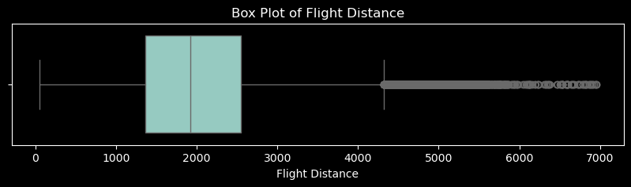

```python
# Box Plot of Flight Distance
plt.figure(figsize=(10, 2))
sns.boxplot(x=df['Flight Distance'])
plt.title('Box Plot of Flight Distance')
plt.xlabel('Flight Distance')
plt.show()
```

```python
# Quartiles and IQR of Flight Distance
Q1_Flight_Distance = df['Flight Distance'].quantile(0.25)
Q2_Flight_Distance = df['Flight Distance'].quantile(0.5)
Q3_Flight_Distance = df['Flight Distance'].quantile(0.75)
IQR_Flight_Distance = Q3_Flight_Distance - Q1_Flight_Distance
print(f"25th Percentile (Q1): {Q1_Flight_Distance:.2f}")
print(f"50th Percentile (Median): {Q2_Flight_Distance:.2f}")
print(f"75th Percentile (Q3): {Q3_Flight_Distance:.2f}")
print(f"Interquartile Range (IQR): {IQR_Flight_Distance:.2f}")
```

```
25th Percentile (Q1): 1359.00
50th Percentile (Median): 1924.00
75th Percentile (Q3): 2543.00
Interquartile Range (IQR): 1184.00
```

### Insights from Box Plot of Flight Distance

- The box plot shows a wide IQR from approximately **1359 km to 2543 km**.
- There are some outliers indicating flights longer than the typical range, up to **6951 km**.
- This suggests the airline also operates some long-haul flights, although they are less common.
- Understanding the spread can help in fleet management and fuel efficiency planning.

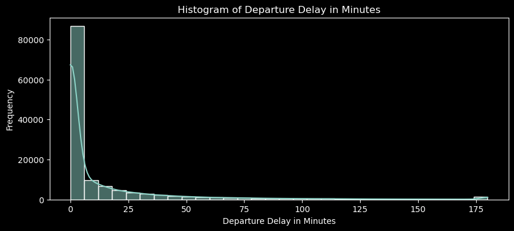

```python
# Histogram of Departure Delay in Minutes
plt.figure(figsize=(10, 4))
sns.histplot(df['Departure Delay in Minutes'], bins=30, kde=True)
plt.title('Histogram of Departure Delay in Minutes')
plt.xlabel('Departure Delay in Minutes')
plt.ylabel('Frequency')
plt.show()
```

```python
# Numerical Summary of Departure Delay in Minutes
mean_Departure_Delay_in_Minutes = df['Departure Delay in Minutes'].mean()
median_Departure_Delay_in_Minutes = df['Departure Delay in Minutes'].median()
std_Departure_Delay_in_Minutes = df['Departure Delay in Minutes'].std()
min_Departure_Delay_in_Minutes = df['Departure Delay in Minutes'].min()
max_Departure_Delay_in_Minutes = df['Departure Delay in Minutes'].max()
print(f"Mean: {mean_Departure_Delay_in_Minutes:.2f}")
print(f"Median: {median_Departure_Delay_in_Minutes:.2f}")
print(f"Standard Deviation: {std_Departure_Delay_in_Minutes:.2f}")
print(f"Minimum: {min_Departure_Delay_in_Minutes:.2f}")
print(f"Maximum: {max_Departure_Delay_in_Minutes:.2f}")
```

```
Mean: 13.79
Median: 0.00
Standard Deviation: 30.77
Minimum: 0.00
Maximum: 180.00
```

### Insights from Histogram of Departure Delay in Minutes

- The majority of flights have **zero departure delay**, indicating good operational efficiency.
- However, there is a long tail towards higher delays, with some flights delayed up to **180 minutes**.
- The mean delay is around **13 minutes**, but the median is **0**, highlighting the impact of outliers.
- Reducing these delays can significantly improve overall customer satisfaction and operational costs.

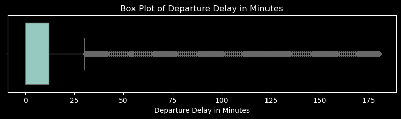

```python
# Box Plot of Departure Delay in Minutes
plt.figure(figsize=(10, 2))
sns.boxplot(x=df['Departure Delay in Minutes'])
plt.title('Box Plot of Departure Delay in Minutes')
plt.xlabel('Departure Delay in Minutes')
plt.show()
```

```python
# Quartiles and IQR of Departure Delay in Minutes
Q1_Departure_Delay_in_Minutes = df['Departure Delay in Minutes'].quantile(0.25)
Q2_Departure_Delay_in_Minutes = df['Departure Delay in Minutes'].quantile(0.5)
Q3_Departure_Delay_in_Minutes = df['Departure Delay in Minutes'].quantile(0.75)
IQR_Departure_Delay_in_Minutes = Q3_Departure_Delay_in_Minutes - Q1_Departure_Delay_in_Minutes
print(f"25th Percentile (Q1): {Q1_Departure_Delay_in_Minutes:.2f}")
print(f"50th Percentile (Median): {Q2_Departure_Delay_in_Minutes:.2f}")
print(f"75th Percentile (Q3): {Q3_Departure_Delay_in_Minutes:.2f}")
print(f"Interquartile Range (IQR): {IQR_Departure_Delay_in_Minutes:.2f}")
```

```
25th Percentile (Q1): 0.00
50th Percentile (Median): 0.00
75th Percentile (Q3): 12.00
Interquartile Range (IQR): 12.00
```

### Insights from Box Plot of Departure Delay in Minutes

- The box plot highlights that the majority of flights have **no departure delay**.
- The IQR is from **0 to 12 minutes**, but there are many outliers extending up to **180 minutes**.
- The presence of these outliers indicates occasional significant delays that could impact customer satisfaction.
- Strategies to manage and reduce these delays could have a substantial positive effect.

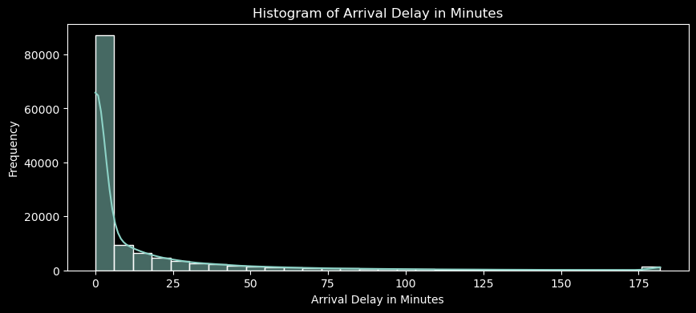

```python
# Histogram of Arrival Delay in Minutes
plt.figure(figsize=(10, 4))
sns.histplot(df['Arrival Delay in Minutes'], bins=30, kde=True)
plt.title('Histogram of Arrival Delay in Minutes')
plt.xlabel('Arrival Delay in Minutes')
plt.ylabel('Frequency')
plt.show()
```

```python
# Numerical Summary of Arrival Delay in Minutes
mean_Arrival_Delay_in_Minutes = df['Arrival Delay in Minutes'].mean()
median_Arrival_Delay_in_Minutes = df['Arrival Delay in Minutes'].median()
std_Arrival_Delay_in_Minutes = df['Arrival Delay in Minutes'].std()
min_Arrival_Delay_in_Minutes = df['Arrival Delay in Minutes'].min()
max_Arrival_Delay_in_Minutes = df['Arrival Delay in Minutes'].max()
print(f"Mean: {mean_Arrival_Delay_in_Minutes:.2f}")
print(f"Median: {median_Arrival_Delay_in_Minutes:.2f}")
print(f"Standard Deviation: {std_Arrival_Delay_in_Minutes:.2f}")
print(f"Minimum: {min_Arrival_Delay_in_Minutes:.2f}")
print(f"Maximum: {max_Arrival_Delay_in_Minutes:.2f}")
```

```
Mean: 14.22
Median: 0.00
Standard Deviation: 31.27
Minimum: 0.00
Maximum: 182.00
```

### Insights from Histogram of Arrival Delay in Minutes

- Similar to departure delays, most flights **arrive on time**, but there is a tail of flights with significant delays.
- The strong correlation with departure delays suggests that late departures often lead to late arrivals.
- Focusing on improving departure punctuality can directly impact arrival times.
- Addressing factors causing arrival delays can enhance the airline's reliability reputation.

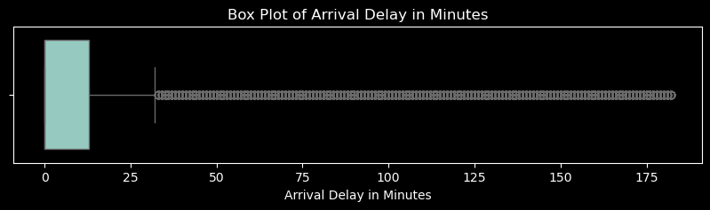

```python
# Box Plot of Arrival Delay in Minutes
plt.figure(figsize=(10, 2))
sns.boxplot(x=df['Arrival Delay in Minutes'])
plt.title('Box Plot of Arrival Delay in Minutes')
plt.xlabel('Arrival Delay in Minutes')
plt.show()
```

```python
# Quartiles and IQR of Arrival Delay in Minutes
Q1_Arrival_Delay_in_Minutes = df['Arrival Delay in Minutes'].quantile(0.25)
Q2_Arrival_Delay_in_Minutes = df['Arrival Delay in Minutes'].quantile(0.5)
Q3_Arrival_Delay_in_Minutes = df['Arrival Delay in Minutes'].quantile(0.75)
IQR_Arrival_Delay_in_Minutes = Q3_Arrival_Delay_in_Minutes - Q1_Arrival_Delay_in_Minutes
print(f"25th Percentile (Q1): {Q1_Arrival_Delay_in_Minutes:.2f}")
print(f"50th Percentile (Median): {Q2_Arrival_Delay_in_Minutes:.2f}")
print(f"75th Percentile (Q3): {Q3_Arrival_Delay_in_Minutes:.2f}")
print(f"Interquartile Range (IQR): {IQR_Arrival_Delay_in_Minutes:.2f}")
```

```
25th Percentile (Q1): 0.00
50th Percentile (Median): 0.00
75th Percentile (Q3): 13.00
Interquartile Range (IQR): 13.00
```

### Insights from Box Plot of Arrival Delay in Minutes

- Similar to departure delays, the arrival delay box plot shows most flights **arrive on time**.
- The IQR ranges from **0 to 13 minutes**, with outliers up to **182 minutes**.
- The outliers suggest that while most flights are punctual, some experience significant delays.
- Addressing these could improve the airline's on-time arrival statistics and customer perception.

## Correlation Matrix and Heatmap

We compute the correlation matrix for the numerical variables to observe relationships between them.

```python
# Compute correlation matrix
corr_matrix = df[numerical_cols].corr()

# Display correlation matrix
corr_matrix
```

|  | Age | Flight Distance | Departure Delay in Minutes | Arrival Delay in Minutes |
| --- | --- | --- | --- | --- |
| Age | 1.000000 | -0.249438 | -0.007749 | -0.010003 |
| Flight Distance | -0.249438 | 1.000000 | 0.107377 | 0.105850 |
| Departure Delay in Minutes | -0.007749 | 0.107377 | 1.000000 | 0.951364 |
| Arrival Delay in Minutes | -0.010003 | 0.105850 | 0.951364 | 1.000000 |

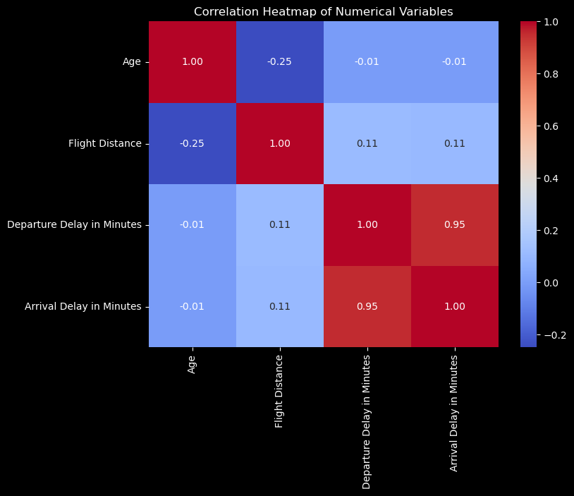

```python
# Plot heatmap
plt.figure(figsize=(8, 6))
sns.heatmap(corr_matrix, annot=True, fmt=".2f", cmap='coolwarm')
plt.title('Correlation Heatmap of Numerical Variables')
plt.show()
```

### Insights from Correlation Matrix and Heatmap

- **Strong Positive Correlation between Departure and Arrival Delays**: The correlation coefficient of approximately **0.95** indicates that flights that depart late tend to arrive late.
- **Negative Correlation between Age and Flight Distance**: A correlation of **-0.25** suggests that younger passengers are more likely to take longer flights, which could be due to travel preferences or business needs.
- **Positive Correlation between Flight Distance and Delays**: Longer flights have a slight tendency to experience more delays, possibly due to increased complexity in operations.
- Understanding these relationships can help the airline in scheduling, resource allocation, and improving customer satisfaction.

# Conclusions and Recommendations

Based on our analysis, we have identified key insights and potential areas for improvement for the airline.

### Key Insights

- **Passenger Demographics**: The airline serves a wide age range, with a significant portion of passengers between **27 and 51 years old**. Younger passengers tend to take longer flights.
- **Flight Operations**: The airline operates a mix of short-haul, medium-haul, and some long-haul flights, as indicated by the bimodal distribution of flight distances.
- **Delays**: While most flights depart and arrive on time, significant delays exist and are highly correlated between departure and arrival times.

### Recommendations

1. **Address Significant Delays**:
   - Investigate root causes such as operational inefficiencies, air traffic congestion, or maintenance issues.
   - Implement predictive maintenance and better scheduling to reduce delays.
2. **Enhance On-Time Performance**:
   - Focus on improving ground operations to expedite boarding and turnaround times.
   - Communicate proactively with passengers about delays to improve satisfaction.
3. **Customer Satisfaction Initiatives**:
   - Develop targeted marketing strategies for different age groups, especially the younger demographic on longer flights.
   - Offer personalized services or loyalty programs to enhance the passenger experience.
4. **Optimize Flight Routes**:
   - Analyze profitability of various routes to focus on high-demand, high-margin flights.
   - Adjust flight frequencies based on demand patterns to improve load factors.

**Conclusion**

By addressing delays, enhancing customer satisfaction, and optimizing operations, the airline can improve overall performance and strengthen its competitive position in the market. Continuous data analysis and monitoring are essential to adapt to changing market conditions and customer needs.